# HW5

#### 107000105 楊晶宇

## Implementation

### 提醒:檔案內用到許多圖片檔，最後predict有用到model檔，因為不知道檔案會不會太大，所以沒上傳，助教需要可以跟我取得，我怕先上傳太佔空間

### Data preprocessing

直接去keras dataset下載檔案

```python
import numpy as np
import pandas as pd
import tensorflow as tf
import keras

(X_train, y_train), (X_test, y_test) = tf.keras.datasets.fashion_mnist.load_data()
```

為了要符合model input形式，將data reshape，並宣告labels

```python
X_train = X_train.reshape(X_train.shape[0], 28, 28, 1)
X_test = X_test.reshape(X_test.shape[0], 28, 28, 1)
labels=['T-shirt/top','Trouser','Pullover','Dress','Coat','Sandal','Shirt','Sneaker','Bag','Ankle boot']
```

把train data前20個畫出來觀察一下，看一下label有沒有錯

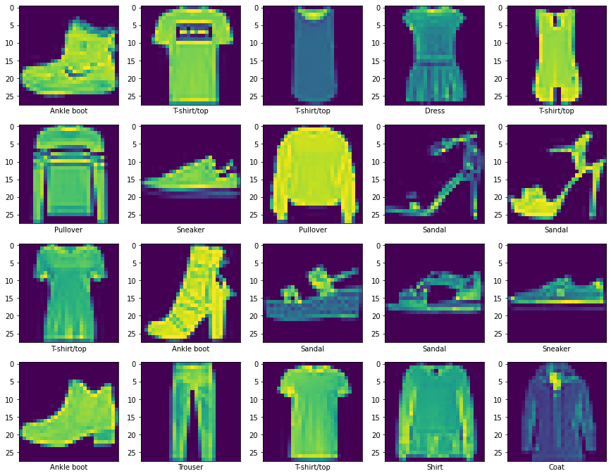

```python
plt.figure(figsize = (15, 15))
for i in range(20):
    plt.subplot(5, 5, i+1)
    plt.xticks([])
    plt.xlabel(labels[y_train[i]])
    plt.imshow(X_train[i].reshape(28, 28))
```

### train test split

因為在training的過程原則上是完全不能看到test data的，所以我們把training data 拆出一部分當 val，**目的是觀察model的穩定性**，看是否設計的model有overfiting的現象，**如果有的話，則要去修改model的架構**(增加drop out或 batch normalization)，讓model穩定，**最後再把val+train用穩定的parameter丟進穩定的model training，得出最好的classifier**

## Model design

### 3layers model

model complexity: **parameters數量為1,937,354**

```python
from tensorflow.keras import Sequential
from tensorflow.keras.layers import Dense, Flatten, Conv2D, MaxPool2D, Dropout, BatchNormalization, Dropout
model = Sequential()

model.add(Conv2D(64, kernel_size=(3, 3), activation='relu', padding='same', input_shape=(28, 28, 1)))
# model.add(BatchNormalization())
model.add(Dropout(rate=0.5))
model.add(Conv2D(64, kernel_size=(3, 3), activation='relu'))
# model.add(BatchNormalization())
model.add(Dropout(rate=0.5))
model.add(MaxPool2D(pool_size=(2, 2)))

model.add(Conv2D(128, kernel_size=(3, 3), activation='relu', padding='same'))
# model.add(BatchNormalization())
model.add(Dropout(rate=0.5))
model.add(Conv2D(128, kernel_size=(3, 3), activation='relu'))
# model.add(BatchNormalization())
model.add(Dropout(rate=0.5))
model.add(MaxPool2D(pool_size=(2, 2)))

model.add(Conv2D(256, kernel_size=(3, 3), activation='relu', padding='same'))
# model.add(BatchNormalization())
model.add(Dropout(rate=0.5))
model.add(Conv2D(256, kernel_size=(3, 3), activation='relu'))
# model.add(BatchNormalization())
model.add(Dropout(rate=0.5))
model.add(MaxPool2D(pool_size=(2, 2)))
model.add(Flatten())
model.add(Dense(1024, activation='relu'))
model.add(Dense(512, activation='relu'))
model.add(Dense(10, activation='softmax'))
model.summary()
```

```
Model: "sequential_4"
_________________________________________________________________
Layer (type)                 Output Shape              Param #
=================================================================
conv2d_9 (Conv2D)            (None, 28, 28, 64)        640
_________________________________________________________________
dropout_6 (Dropout)          (None, 28, 28, 64)        0
_________________________________________________________________
conv2d_10 (Conv2D)           (None, 26, 26, 64)        36928
_________________________________________________________________
dropout_7 (Dropout)          (None, 26, 26, 64)        0
_________________________________________________________________
max_pooling2d_4 (MaxPooling2 (None, 13, 13, 64)        0
_________________________________________________________________
conv2d_11 (Conv2D)           (None, 13, 13, 128)       73856
_________________________________________________________________
dropout_8 (Dropout)          (None, 13, 13, 128)       0
_________________________________________________________________
conv2d_12 (Conv2D)           (None, 11, 11, 128)       147584
_________________________________________________________________
dropout_9 (Dropout)          (None, 11, 11, 128)       0
_________________________________________________________________
max_pooling2d_5 (MaxPooling2 (None, 5, 5, 128)         0
_________________________________________________________________
conv2d_13 (Conv2D)           (None, 5, 5, 256)         295168
_________________________________________________________________
dropout_10 (Dropout)         (None, 5, 5, 256)         0
_________________________________________________________________
conv2d_14 (Conv2D)           (None, 3, 3, 256)         590080
_________________________________________________________________
dropout_11 (Dropout)         (None, 3, 3, 256)         0
_________________________________________________________________
max_pooling2d_6 (MaxPooling2 (None, 1, 1, 256)         0
_________________________________________________________________
flatten_2 (Flatten)          (None, 256)               0
_________________________________________________________________
dense_4 (Dense)              (None, 1024)              263168
_________________________________________________________________
dense_5 (Dense)              (None, 512)               524800
_________________________________________________________________
dense_6 (Dense)              (None, 10)                5130
=================================================================
Total params: 1,937,354
Trainable params: 1,937,354
Non-trainable params: 0
_________________________________________________________________
```

### 2layers model

後來發現2層的model沒有比較差，雖然層數比較少，但是最後穩定停在的ACC比3層的還要高，**後面的分析會分成兩部分，一部份是3layers，一部分是2layers**

model complexity: **parameters數量為703,762**，大約是3layers的0.36倍

```python
from tensorflow.keras import Sequential
from tensorflow.keras.layers import Dense, Flatten, Conv2D, MaxPool2D, Dropout, BatchNormalization, Dropout

model = Sequential()
model.add(Conv2D(64, (3, 3), activation='relu', input_shape = X_train.shape[1:]))
model.add(Conv2D(64, (3, 3), activation='relu'))
model.add(MaxPool2D((2, 2), padding='same'))
model.add(Dropout(0.5))
# model.add(BatchNormalization())

model.add(Conv2D(128, (3, 3), activation='relu'))
model.add(Conv2D(128, (3, 3), activation='relu'))
model.add(MaxPool2D((2, 2), padding='same'))
model.add(Dropout(0.5))
# model.add(BatchNormalization())

model.add(Flatten())
model.add(Dense(216, activation='relu'))
model.add(Dropout(0.5))
# model.add(BatchNormalization())
model.add(Dense(10, activation='softmax'))
model.summary()
```

```
Model: "sequential_5"
_________________________________________________________________
Layer (type)                 Output Shape              Param #
=================================================================
conv2d_15 (Conv2D)           (None, 26, 26, 64)        640
_________________________________________________________________
conv2d_16 (Conv2D)           (None, 24, 24, 64)        36928
_________________________________________________________________
max_pooling2d_7 (MaxPooling2 (None, 12, 12, 64)        0
_________________________________________________________________
dropout_12 (Dropout)         (None, 12, 12, 64)        0
_________________________________________________________________
conv2d_17 (Conv2D)           (None, 10, 10, 128)       73856
_________________________________________________________________
conv2d_18 (Conv2D)           (None, 8, 8, 128)         147584
_________________________________________________________________
max_pooling2d_8 (MaxPooling2 (None, 4, 4, 128)         0
_________________________________________________________________
dropout_13 (Dropout)         (None, 4, 4, 128)         0
_________________________________________________________________
flatten_3 (Flatten)          (None, 2048)              0
_________________________________________________________________
dense_7 (Dense)              (None, 216)               442584
_________________________________________________________________
dropout_14 (Dropout)         (None, 216)               0
_________________________________________________________________
dense_8 (Dense)              (None, 10)                2170
=================================================================
Total params: 703,762
Trainable params: 703,762
Non-trainable params: 0
_________________________________________________________________
```

```python
model = Sequential()
model.add(Conv2D(64, (3, 3), activation='relu', input_shape = X_train.shape[1:]))
model.add(Conv2D(64, (3, 3), activation='relu'))
model.add(MaxPool2D((2, 2), padding='same'))
model.add(Dropout(0.25))
# model.add(BatchNormalization())

model.add(Conv2D(128, (3, 3), activation='relu'))
model.add(Conv2D(128, (3, 3), activation='relu'))
model.add(MaxPool2D((2, 2), padding='same'))
model.add(Dropout(0.25))
# model.add(BatchNormalization())

model.add(Flatten())
model.add(Dense(216, activation='relu'))
model.add(Dropout(0.5))
# model.add(BatchNormalization())
model.add(Dense(10, activation='softmax'))
model.summary()
```

```
Model: "sequential_3"
_________________________________________________________________
Layer (type)                 Output Shape              Param #
=================================================================
conv2d_5 (Conv2D)            (None, 26, 26, 64)        640
_________________________________________________________________
conv2d_6 (Conv2D)            (None, 24, 24, 64)        36928
_________________________________________________________________
max_pooling2d_2 (MaxPooling2 (None, 12, 12, 64)        0
_________________________________________________________________
dropout_3 (Dropout)          (None, 12, 12, 64)        0
_________________________________________________________________
conv2d_7 (Conv2D)            (None, 10, 10, 128)       73856
_________________________________________________________________
conv2d_8 (Conv2D)            (None, 8, 8, 128)         147584
_________________________________________________________________
max_pooling2d_3 (MaxPooling2 (None, 4, 4, 128)         0
_________________________________________________________________
dropout_4 (Dropout)          (None, 4, 4, 128)         0
_________________________________________________________________
flatten_1 (Flatten)          (None, 2048)              0
_________________________________________________________________
dense_2 (Dense)              (None, 216)               442584
_________________________________________________________________
dropout_5 (Dropout)          (None, 216)               0
_________________________________________________________________
dense_3 (Dense)              (None, 10)                2170
=================================================================
Total params: 703,762
Trainable params: 703,762
Non-trainable params: 0
_________________________________________________________________
```

由於epochs如果設太大，training我自己電腦會跑不動，所以我都用**google colab提供的免費GPU跑**，這樣epoch就可以設大一點

```python
from keras import optimizers

lr = 0.005
epochs = 250
batch_size = 1024

optimizer = optimizers.Adagrad(lr=lr)
model.compile(optimizer=optimizer, loss='sparse_categorical_crossentropy', metrics = ['accuracy'])
```

```python
history = model.fit(X_train, y_train, batch_size = batch_size, epochs = epochs, validation_data = (X_val, y_val))
```

### Model Selection and Parameter Selection

主要是把loss跟ACC的趨勢圖畫出來，分析哪一個model配parameters在testing set上面表現會比較好，選擇作為最後的momdel跟parameters

#### 圖片都存下來，後面一起分析

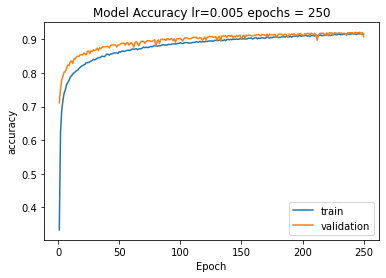

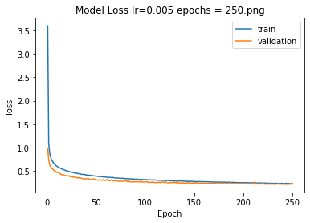

```python
import matplotlib.pyplot as plt
plt.title('Model Accuracy lr=' + str(lr) + ' epochs = ' + str(epochs))
plt.plot(range(1, epochs+1), history.history['accuracy'])
plt.plot(range(1, epochs+1), history.history['val_accuracy'])
plt.xlabel('Epoch')
plt.ylabel('accuracy')
plt.legend(labels=['train','validation'])
plt.show()
plt.savefig('Model_Accuracy_lr_' + str(lr) + '_epochs_' + str(epochs) + '.png')

plt.title('Model Loss lr=' + str(lr) + ' epochs = ' + str(epochs) + '.png')
plt.plot(range(1, epochs+1),history.history['loss'])
plt.plot(range(1, epochs+1),history.history['val_loss'])
plt.xlabel('Epoch')
plt.ylabel('loss')
plt.legend(labels=['train','validation'])
plt.show()
plt.savefig('Model_Loss_lr_' + str(lr) + '_epochs_' + str(epochs) + '.png')
```

### 下面會把所有試過的model跟參數整理比較(圖上標題都有紀錄參數)：

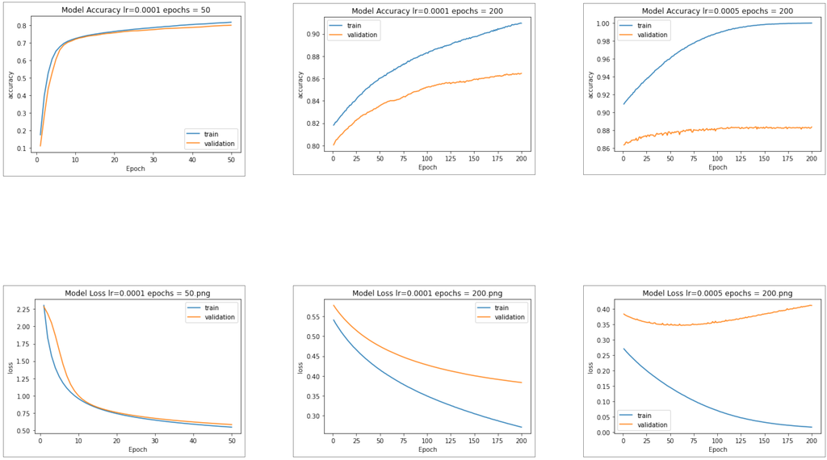

```python
import matplotlib.pyplot as plt
img_acc_list = []
img_acc_list.append(plt.imread('pic/5.png'))
img_acc_list.append(plt.imread('pic/8.png'))
img_acc_list.append(plt.imread('pic/11.png'))
img_loss_list = []
img_loss_list.append(plt.imread('pic/6.png'))
img_loss_list.append(plt.imread('pic/9.png'))
img_loss_list.append(plt.imread('pic/12.png'))

plt.figure(figsize = (50, 50))
j = 1
for i in range(3):
    plt.subplot(3, 3, j)
    plt.xticks([])
    plt.yticks([])
    plt.imshow(img_acc_list[i])
    j = j+1
for i in range(3):
    plt.subplot(3, 3, j)
    plt.xticks([])
    plt.yticks([])
    plt.imshow(img_loss_list[i])
    j = j + 1
```

### 3layers bactchsize normalization model(上面的figure)

1.最左邊一排是第一次試，發現還沒train完整，ACC還在上升，所以把epochs加到200  
2.中間那排是加到200，發現還是沒train完，所以決定調大learning rate，不然太花時間了  
3.最右邊的是learning rate調大後的結果，發現val ACC穩定在0.88附近震盪，train set也train到接近100%，但是val loss最後增加了

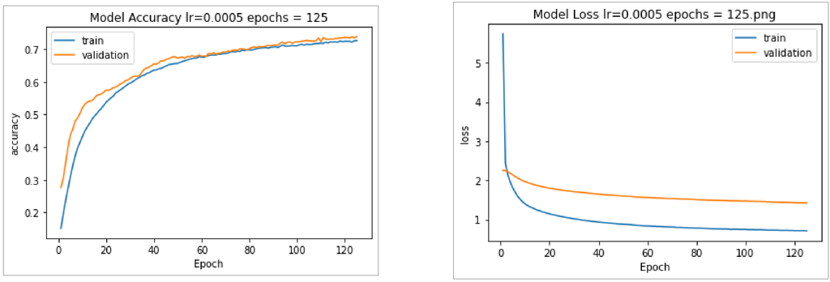

```python
import matplotlib.pyplot as plt
img_acc_list = []
img_acc_list.append(plt.imread('pic/15_dropout.png'))
img_loss_list = []
img_loss_list.append(plt.imread('pic/16_dropout.png'))


plt.figure(figsize = (50, 50))
j = 1
for i in range(1):
    plt.subplot(1, 2, j)
    plt.xticks([])
    plt.yticks([])
    plt.imshow(img_acc_list[i])
    j = j+1
for i in range(1):
    plt.subplot(1, 2, j)
    plt.xticks([])
    plt.yticks([])
    plt.imshow(img_loss_list[i])
    j = j + 1
```

### 3layers dropout model(上面的figure)

測試3layers dropout發現和batch normalization同樣的learning rate，epoch到120還只停在0.71左右，上升的速度比batch normalization 慢很多(**可以對比上一張figure最右邊的圖，epochs在125的時候model已經穩定且到達0.88了**)，感覺要train完要調大更多的epochs，跑的時間太久了，所以就沒有train了，直接把model complexity降低，試2層的model

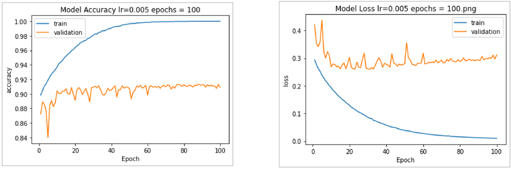

```python
import matplotlib.pyplot as plt
img_acc_list = []
img_acc_list.append(plt.imread('pic/17.png'))
img_loss_list = []
img_loss_list.append(plt.imread('pic/18.png'))


plt.figure(figsize = (50, 50))
j = 1
for i in range(1):
    plt.subplot(1, 2, j)
    plt.xticks([])
    plt.yticks([])
    plt.imshow(img_acc_list[i])
    j = j+1
for i in range(1):
    plt.subplot(1, 2, j)
    plt.xticks([])
    plt.yticks([])
    plt.imshow(img_loss_list[i])
    j = j + 1
```

### 2layers batch normalization model(上面的figure)

感覺validation前面震盪很嚴重，但是後面有逐漸穩定的趨勢，train也有接近99%，但是val的loss最後有在上升的趨勢，先試試看2 layers的dropout

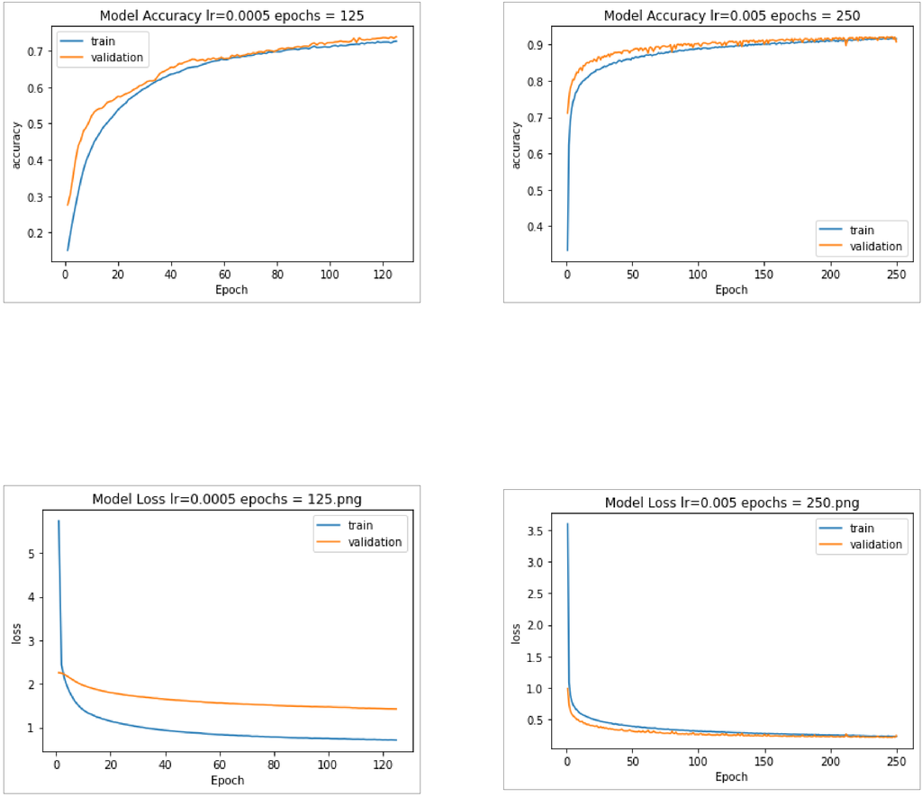

```python
import matplotlib.pyplot as plt
img_acc_list = []
img_acc_list.append(plt.imread('pic/15_dropout.png'))
img_acc_list.append(plt.imread('pic/19_dropout.png'))
img_loss_list = []
img_loss_list.append(plt.imread('pic/16_dropout.png'))
img_loss_list.append(plt.imread('pic/20_dropout.png'))



plt.figure(figsize = (50, 50))
j = 1
for i in range(2):
    plt.subplot(2, 2, j)
    plt.xticks([])
    plt.yticks([])
    plt.imshow(img_acc_list[i])
    j = j+1
for i in range(2):
    plt.subplot(2, 2, j)
    plt.xticks([])
    plt.yticks([])
    plt.imshow(img_loss_list[i])
    j = j + 1
```

## training all training dataset

```python
X_train = np.vstack((X_train, X_val))
y_train = np.hstack((y_train, y_val))
```

```python
model.compile(optimizer=optimizer, loss='sparse_categorical_crossentropy', metrics = ['accuracy'])

lr = 0.0005
epochs = 75
batch_size = 1024

model.fit(X_train, y_train, batch_size = batch_size, epochs = epochs, validation_data = (X_val, y_val))
```

```
<tensorflow.python.keras.callbacks.History at 0x7f5b6fb36748>
```

## final results

```
WARNING:tensorflow:Error in loading the saved optimizer state. As a result, your model is starting with a freshly initialized optimizer.
```

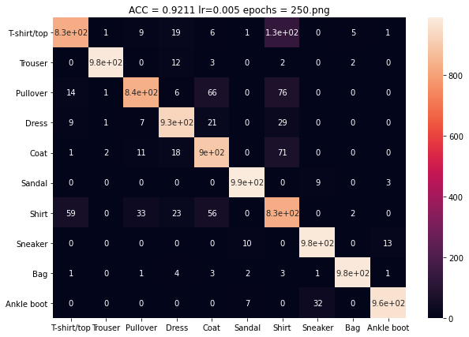

```python
from keras.models import load_model
model = keras.models.load_model('final.h5')
from sklearn.metrics import accuracy_score
y_pred = np.argmax(model.predict(X_test), axis=-1)
acc = accuracy_score(y_test, y_pred)
from sklearn.metrics import confusion_matrix, ConfusionMatrixDisplay
import seaborn as sn
import pandas as pd
import matplotlib.pyplot as plt

cm = confusion_matrix(y_test, y_pred)
df_cm = pd.DataFrame(cm, index = labels,
                  columns = labels)
plt.figure(figsize = (10,7))
plt.title('ACC = '+ str(acc) + ' lr=' + str(lr) + ' epochs = ' + str(epochs) + '.png')
sn.heatmap(df_cm, annot=True)
```

## conclusion

這次的作業學到滿多的，主要是如何選擇model與條整參數，我發現以下幾點：

1.三層的CNN沒有比兩層的好，層數越多不代表ACC就會越高  
2.dropout跑的速度比batch normalization慢，但是結果不一定比較差，跑得夠久，還是可以穩定下來  
3.learning rate越小，上升的速度越慢，train完的時間需要得越久

整個作業做完更了解CNN架構，也學會怎麼運用免費的GPU去跑實驗，測試比較大的epoch跟batchsize，很有成就感